# Vestimenta, confianza y decisiones en un juego de votaciones

Proyecto final · Introducción a la Ciencia de Datos

2026-11-18

Este informe adapta el archivo `codigo/analisis datos experimento.Rmd` a nuestros datos. Sigue el orden del archivo base de la profesora: datos, tabla descriptiva, asociación, gráficos, aumentación de datos y modelo. Los comentarios finales incorporan los apuntes del equipo sobre N, causalidad y críticas al juego. La tabla descriptiva, los tests de asociación y el remuestreo provienen del ejemplo de la profesora; las uniones y gráficas, de las clases 7 y 9; y los modelos lineales, de la clase 12. No se ejecutan scripts de clase que descarguen otras bases o instalen paquetes automáticamente.

**Pregunta:** ¿Cómo se relacionan los hábitos de vestimenta y la influencia de la ropa sobre la confianza con la seguridad declarada y los cambios de elección en el juego?

## Paquetes

Abrir primero `lab-laboratorio-experimento.Rproj` y luego este archivo. Las rutas parten de la raíz del proyecto, igual que en los ejemplos con `here`. Los datos que usa el informe están en `datos/crudos`; el HTML generado con Knit se guarda en `resultados`.

```r
# Si falta alguno, instalarlo una sola vez desde la consola:
# install.packages(c("dplyr", "readr", "here", "ggplot2",
#                    "gtsummary", "effectsize"))
library(dplyr)
library(readr)
library(here)
library(ggplot2)
library(gtsummary)
library(effectsize)
```

# Datos: cargar encuesta y juego

La encuesta recoge características de los estudiantes, hábitos de cuidado personal y criterios de vestimenta. El juego registra una elección entre cuatro actividades y su seguridad, antes y después de mostrar resultados grupales. El código de participante `id` (P01, P02, …) es el mismo en ambos instrumentos y permite vincularlos sin publicar los correos.

Los cuatro CSV de `datos/crudos` proceden del proceso de `codigo/00_anonimizar.R`. Ese script normaliza los correos, asigna un código consistente a cada participante y guarda la correspondencia en `datos/originales`, fuera de los archivos versionados. El informe usa los CSV ya preparados; no necesita acceder a los correos ni volver a ejecutar la anonimización. Cada tabla tiene su diccionario de variables.

```r
encuesta_cruda <- read_csv(
  here("datos/crudos/encuesta.csv"), show_col_types = FALSE
)
juego_crudo <- read_csv(
  here("datos/crudos/juego.csv"), show_col_types = FALSE
)
diccionario_encuesta <- read_csv(
  here("datos/crudos/diccionario_encuesta.csv"), show_col_types = FALSE
)
diccionario_juego <- read_csv(
  here("datos/crudos/diccionario_juego.csv"), show_col_types = FALSE
)
```

**Alcance de la fuente.** Una fila de encuesta representa una respuesta, no necesariamente una persona distinta. Una fila del juego contiene las dos rondas de un identificador. Los archivos no incluyen una columna que distinga observaciones recogidas de observaciones sintéticas. Antes de presentar el trabajo, el equipo debe documentar cuáles registros, si los hay, fueron generados, con qué procedimiento y cuántos participantes efectivos hubo. El informe describe los archivos disponibles; sus filas no certifican por sí mismas ese número de participantes reales.

No constan aquí el número de personas invitadas ni el de quienes rechazaron participar: no se calcula una tasa de respuesta. Tampoco se reconstruye el cuestionario completo a partir de los nombres de las variables. Para la entrega, debe acompañarse con el formulario y las instrucciones originales del juego.

## Revisar los datos originales

El perfilado diagnostica sin modificar las tablas. Los datos usados por el informe ya identifican a los participantes mediante códigos.

```r
# Funciones, sapply(), is.na(), unique(), min() y max(): clases 3, 5, 7 y 9.
perfil <- function(datos) {
  tibble(
    variable = names(datos),
    tipo = sapply(datos, function(x) class(x)[1]),
    distintos = sapply(datos, function(x) length(unique(x[!is.na(x)]))),
    faltantes = sapply(datos, function(x) sum(is.na(x))),
    minimo = sapply(datos, function(x) {
      if (is.numeric(x) && sum(!is.na(x)) > 0) min(x, na.rm = TRUE) else NA_real_
    }),
    maximo = sapply(datos, function(x) {
      if (is.numeric(x) && sum(!is.na(x)) > 0) max(x, na.rm = TRUE) else NA_real_
    })
  )
}
dim(encuesta_cruda)
```

```
## [1] 39 34
```

```r
dim(juego_crudo)
```

```
## [1] 34  5
```

```r
perfil(encuesta_cruda)
```

```
## # A tibble: 34 × 6
##    variable             tipo      distintos faltantes minimo maximo
##    <chr>                <chr>         <int>     <int>  <dbl>  <dbl>
##  1 id                   character        36         0     NA     NA
##  2 fecha_respuesta      character        39         0     NA     NA
##  3 consentimiento       numeric           1         0      1      1
##  4 sexo                 numeric           2         0      0      1
##  5 edad                 numeric           6         0     19     26
##  6 anio_carrera         numeric           4         0      2      5
##  7 carrera              numeric           5         0      1      6
##  8 carrera_otro_detalle logical           0        39     NA     NA
##  9 frec_peluqueria      numeric           6         0      1      8
## 10 se_peina             numeric           2         0      0      1
## # ℹ 24 more rows
```

```r
perfil(juego_crudo)
```

```
## # A tibble: 5 × 6
##   variable         tipo      distintos faltantes minimo maximo
##   <chr>            <chr>         <int>     <int>  <dbl>  <dbl>
## 1 id               character        34         0     NA     NA
## 2 ronda1_eleccion  numeric           4         0      1      4
## 3 ronda1_seguridad numeric           5         0      1      5
## 4 ronda2_eleccion  numeric           4         0      1      4
## 5 ronda2_seguridad numeric           3         0      3      5
```

```r
# Filas idénticas y repeticiones de la clave son problemas diferentes.
sum(duplicated(encuesta_cruda))
```

```
## [1] 0
```

```r
sum(duplicated(juego_crudo))
```

```
## [1] 0
```

```r
encuesta_cruda |> count(id) |> count(n, name = "cantidad_de_codigos")
```

```
## # A tibble: 2 × 2
##       n cantidad_de_codigos
##   <int>               <int>
## 1     1                  33
## 2     2                   3
```

```r
juego_crudo |> count(id) |> count(n, name = "cantidad_de_codigos")
```

```
## # A tibble: 1 × 2
##       n cantidad_de_codigos
##   <int>               <int>
## 1     1                  34
```

El diccionario de encuesta indica que **0 es una respuesta válida** en las variables binarias y en algunos tiempos; no se reemplaza por NA. `carrera_otro_detalle` puede estar vacío por el diseño de la pregunta. Las frecuencias y los tiempos están codificados por categorías: un 7 en peluquería no significa siete visitas. Los códigos no tienen distancias iguales.

El diccionario actual del juego usa los nombres `ronda1_eleccion` y `ronda2_eleccion`. El proceso de preparación corrigió el diccionario anterior, que conservaba otros nombres y mencionaba carta y segunda opción. Esas columnas no están en los datos actuales y no se inventan.

# Tabla descriptiva

## Respuestas originales: todas las preguntas

En esta etapa describimos **todas las respuestas tal como están guardadas**. No eliminamos duplicados, no elegimos la primera respuesta, no imputamos, no creamos índices ni calculamos cambios entre rondas. Por eso N significa **respuestas registradas**, no necesariamente personas distintas. El perfilado anterior informa las repeticiones; su tratamiento para el modelo se realiza después de la aumentación.

La tabla anterior era una selección incompleta. Ahora incluimos todas las preguntas de encuesta y las cuatro respuestas originales del juego. **Frecuencia de peluquería sí es una pregunta original** (`frec_peluqueria`); `cambio_voto`, en cambio, es un indicador calculado y no pertenece a esta etapa.

Para mostrar los códigos con sus nombres, hacemos copias de presentación: `encuesta_descriptiva` y `juego_descriptivo`. Solo asignamos etiquetas del diccionario, manteniendo nombres de variables, filas, faltantes y respuestas. Las tablas crudas no se modifican. Etiquetar 0 como «No» no es construir una respuesta nueva ni convertir una categoría en cantidad.

```r
encuesta_descriptiva <- encuesta_cruda
binarias_encuesta <- c(
  "consentimiento", "se_peina", "piensa_ropa_fac",
  "fac_comodidad", "fac_clima", "fac_estilo", "fac_ropa_limpia",
  "fac_como_me_veo", "fac_como_me_ven", "fac_formalidad",
  "piensa_ropa_trab", "trab_comodidad", "trab_clima", "trab_estilo",
  "trab_ropa_limpia", "trab_como_me_veo", "trab_como_me_ven", "trab_formalidad",
  "cambia_segun_personas", "repite_outfit"
)
for (v in binarias_encuesta) {
  encuesta_descriptiva[[v]] <- factor(encuesta_cruda[[v]],
    levels = c(0, 1), labels = c("No", "Sí"))
}
etiquetas_peluqueria <- c("Más de 6 meses", "Cada 6 meses", "Cada 5 meses",
  "Cada 4 meses", "Cada 3 meses", "Cada 2 meses", "1 vez al mes",
  "2 veces al mes", "1 vez a la semana", "Más de 1 vez a la semana")
etiquetas_confianza <- c("No influye", "Impacto moderado", "Influye significativamente")
etiquetas_tiempo <- c("No lo hago", "Unas horas/minutos antes", "La noche anterior",
  "Un día antes", "Dos días antes", "La semana previa", "Un mes antes")
encuesta_descriptiva <- encuesta_descriptiva |>
  mutate(
    sexo = factor(sexo, levels = c(0, 1), labels = c("Femenino", "Masculino")),
    anio_carrera = factor(anio_carrera, levels = 1:6),
    carrera = factor(carrera, levels = 1:8, labels = c("Finanzas",
      "Ciencia de Datos para Negocios", "Administración de Empresas",
      "Negocios Internacionales", "Economía", "Contador Público", "Marketing", "Otro")),
    frec_peluqueria = factor(frec_peluqueria, levels = 1:10, labels = etiquetas_peluqueria),
    tiempo_ropa_fac = factor(tiempo_ropa_fac, levels = 0:6, labels = etiquetas_tiempo),
    tiempo_ropa_trab = factor(tiempo_ropa_trab, levels = 0:6, labels = etiquetas_tiempo),
    tiempo_arreglo_fac = factor(tiempo_arreglo_fac, levels = 1:3,
      labels = c("Menos de 15 minutos", "Entre 15 y 30 minutos", "Más de 1 hora")),
    frec_compra_ropa = factor(frec_compra_ropa, levels = 1:5,
      labels = c("Una vez cada más de 2 meses", "Una vez cada 2 meses",
                 "Una vez por mes", "Una vez cada 2 semanas", "Todas las semanas")),
    importancia_marca = factor(importancia_marca, levels = 1:3,
      labels = c("Poca", "Moderada", "Mucha importancia")),
    confianza_ropa = factor(confianza_ropa, levels = 1:3, labels = etiquetas_confianza)
  )

juego_descriptivo <- juego_crudo
for (v in c("ronda1_eleccion", "ronda2_eleccion")) {
  juego_descriptivo[[v]] <- factor(juego_crudo[[v]], levels = 1:4,
    labels = c("Lógica", "Mímica", "Dibujo", "Memoria"))
}
for (v in c("ronda1_seguridad", "ronda2_seguridad")) {
  juego_descriptivo[[v]] <- factor(juego_crudo[[v]], levels = 1:5,
    labels = c("1: mínima", "2", "3", "4", "5: máxima"))
}
```

### Encuesta completa

Las columnas muestran el total y el desglose por sexo. Sexo se describe además en su propia tabla porque, al usarse como agrupador, no aparece como fila de la tabla principal. Edad se presenta con media y desvío; todas las escalas y opciones se muestran como categorías. Las preguntas de selección múltiple incluyen **cada opción** para facultad y trabajo.

```r
tabla_sexo <- encuesta_descriptiva |>
  select(sexo) |>
  tbl_summary(label = list(sexo ~ "Sexo biológico")) |>
  add_n() |> bold_labels()
tabla_sexo
```

| **Characteristic** | **N** | **N = 39**<sup>1</sup> |
| --- | --- | --- |
| Sexo biológico | 39 |  |
| Femenino |  | 15 (38%) |
| Masculino |  | 24 (62%) |

<sup>1</sup> n (%)

```r
tabla <- encuesta_descriptiva |>
  select(-id, -fecha_respuesta) |>
  tbl_summary(
    by = sexo,
    type = list(edad ~ "continuous", carrera_otro_detalle ~ "categorical"),
    statistic = list(edad ~ "{mean} ({sd})"),
    label = list(
      consentimiento ~ "Acepta participar",
      edad ~ "Edad (años)", anio_carrera ~ "Año de carrera",
      carrera ~ "Carrera principal", carrera_otro_detalle ~ "Detalle de otra carrera",
      frec_peluqueria ~ "Frecuencia de peluquería o barbería",
      se_peina ~ "Se peina antes de venir a la Universidad",
      piensa_ropa_fac ~ "Piensa con antelación la ropa para facultad",
      tiempo_ropa_fac ~ "Cuánto antes piensa la ropa para facultad",
      fac_comodidad ~ "Facultad: comodidad",
      fac_clima ~ "Facultad: clima", fac_estilo ~ "Facultad: estilo y combinación",
      fac_ropa_limpia ~ "Facultad: lo primero que encuentra limpio",
      fac_como_me_veo ~ "Facultad: cómo se ve con la ropa",
      fac_como_me_ven ~ "Facultad: cómo lo ven los demás",
      fac_formalidad ~ "Facultad: formalidad exigida",
      tiempo_arreglo_fac ~ "Tiempo para arreglarse antes de facultad",
      piensa_ropa_trab ~ "Piensa con antelación la ropa para trabajar",
      tiempo_ropa_trab ~ "Cuánto antes piensa la ropa para trabajar",
      trab_comodidad ~ "Trabajo: comodidad", trab_clima ~ "Trabajo: clima",
      trab_estilo ~ "Trabajo: estilo y combinación",
      trab_ropa_limpia ~ "Trabajo: lo primero que encuentra limpio",
      trab_como_me_veo ~ "Trabajo: cómo se ve con la ropa",
      trab_como_me_ven ~ "Trabajo: cómo lo ven los demás",
      trab_formalidad ~ "Trabajo: formalidad exigida",
      frec_compra_ropa ~ "Frecuencia de compra de ropa",
      importancia_marca ~ "Importancia de la marca",
      confianza_ropa ~ "Influencia de la ropa sobre la confianza",
      cambia_segun_personas ~ "Cambia ropa según con quién estará",
      repite_outfit ~ "Repite outfit en la semana sin problema"
    )
  ) |>
  add_overall() |> add_n() |> bold_labels()
tabla
```

| **Characteristic** | **N** | **Overall** N = 39<sup>1</sup> | **Femenino** N = 15<sup>1</sup> | **Masculino** N = 24<sup>1</sup> |
| --- | --- | --- | --- | --- |
| Acepta participar | 39 |  |  |  |
| No |  | 0 (0%) | 0 (0%) | 0 (0%) |
| Sí |  | 39 (100%) | 15 (100%) | 24 (100%) |
| Edad (años) | 39 | 20.79 (1.45) | 20.80 (1.42) | 20.79 (1.50) |
| Año de carrera | 39 |  |  |  |
| 1 |  | 0 (0%) | 0 (0%) | 0 (0%) |
| 2 |  | 18 (46%) | 5 (33%) | 13 (54%) |
| 3 |  | 12 (31%) | 4 (27%) | 8 (33%) |
| 4 |  | 7 (18%) | 5 (33%) | 2 (8.3%) |
| 5 |  | 2 (5.1%) | 1 (6.7%) | 1 (4.2%) |
| 6 |  | 0 (0%) | 0 (0%) | 0 (0%) |
| Carrera principal | 39 |  |  |  |
| Finanzas |  | 15 (38%) | 7 (47%) | 8 (33%) |
| Ciencia de Datos para Negocios |  | 19 (49%) | 4 (27%) | 15 (63%) |
| Administración de Empresas |  | 1 (2.6%) | 1 (6.7%) | 0 (0%) |
| Negocios Internacionales |  | 0 (0%) | 0 (0%) | 0 (0%) |
| Economía |  | 2 (5.1%) | 1 (6.7%) | 1 (4.2%) |
| Contador Público |  | 2 (5.1%) | 2 (13%) | 0 (0%) |
| Marketing |  | 0 (0%) | 0 (0%) | 0 (0%) |
| Otro |  | 0 (0%) | 0 (0%) | 0 (0%) |
| Detalle de otra carrera | 0 |  |  |  |
| FALSE |  | 0 (NA%) | 0 (NA%) | 0 (NA%) |
| TRUE |  | 0 (NA%) | 0 (NA%) | 0 (NA%) |
| Unknown |  | 39 | 15 | 24 |
| Frecuencia de peluquería o barbería | 39 |  |  |  |
| Más de 6 meses |  | 8 (21%) | 7 (47%) | 1 (4.2%) |
| Cada 6 meses |  | 3 (7.7%) | 3 (20%) | 0 (0%) |
| Cada 5 meses |  | 0 (0%) | 0 (0%) | 0 (0%) |
| Cada 4 meses |  | 0 (0%) | 0 (0%) | 0 (0%) |
| Cada 3 meses |  | 8 (21%) | 5 (33%) | 3 (13%) |

[output cut: 96 more lines]

<sup>1</sup> n (%); Mean (SD)

El código de participante y la fecha son metadatos de identificación, no preguntas a resumir en porcentajes. No se publican direcciones de correo. `carrera_otro_detalle` se mantiene visible aunque esté vacío; eso no permite inventar respuestas. Los NA se informan como faltantes. Un cero de una opción binaria es una respuesta, no un faltante.

No añadimos p-valores a esta descriptiva cruda: hay códigos repetidos y sería incorrecto suponer que todas sus filas son personas independientes. Los tests se calculan después de explicitar la selección de observaciones para el análisis. Se conserva `tbl_summary()`, `add_overall()` y `add_n()` del archivo de la profesora.

### Juego: las dos rondas completas

```r
tabla_juego <- juego_descriptivo |>
  select(-id) |>
  tbl_summary(label = list(
    ronda1_eleccion ~ "Primera ronda: actividad elegida",
    ronda1_seguridad ~ "Primera ronda: seguridad de la elección",
    ronda2_eleccion ~ "Segunda ronda: actividad elegida",
    ronda2_seguridad ~ "Segunda ronda: seguridad de la elección"
  )) |> add_n() |> bold_labels()
tabla_juego
```

| **Characteristic** | **N** | **N = 34**<sup>1</sup> |
| --- | --- | --- |
| Primera ronda: actividad elegida | 34 |  |
| Lógica |  | 10 (29%) |
| Mímica |  | 9 (26%) |
| Dibujo |  | 9 (26%) |
| Memoria |  | 6 (18%) |
| Primera ronda: seguridad de la elección | 34 |  |
| 1: mínima |  | 1 (2.9%) |
| 2 |  | 3 (8.8%) |
| 3 |  | 7 (21%) |
| 4 |  | 10 (29%) |
| 5: máxima |  | 13 (38%) |
| Segunda ronda: actividad elegida | 34 |  |
| Lógica |  | 12 (35%) |
| Mímica |  | 8 (24%) |
| Dibujo |  | 10 (29%) |
| Memoria |  | 4 (12%) |
| Segunda ronda: seguridad de la elección | 34 |  |
| 1: mínima |  | 0 (0%) |
| 2 |  | 0 (0%) |
| 3 |  | 2 (5.9%) |
| 4 |  | 5 (15%) |
| 5: máxima |  | 27 (79%) |

<sup>1</sup> n (%)

El juego aporta 34 registros con las dos rondas. No se cuentan como el doble de personas. Aquí no aparece todavía «cambio de voto»: solo mostramos las respuestas originales de cada ronda.

## Caracterizar lo que respondieron

```r
encuesta_descriptiva |> count(sexo) |> mutate(porcentaje = 100 * n / sum(n))
```

```
## # A tibble: 2 × 3
##   sexo          n porcentaje
##   <fct>     <int>      <dbl>
## 1 Femenino     15       38.5
## 2 Masculino    24       61.5
```

```r
encuesta_descriptiva |> count(carrera) |> mutate(porcentaje = 100 * n / sum(n))
```

```
## # A tibble: 5 × 3
##   carrera                            n porcentaje
##   <fct>                          <int>      <dbl>
## 1 Finanzas                          15      38.5
## 2 Ciencia de Datos para Negocios    19      48.7
## 3 Administración de Empresas         1       2.56
## 4 Economía                           2       5.13
## 5 Contador Público                   2       5.13
```

```r
summary(encuesta_cruda$edad)
```

```
##    Min. 1st Qu.  Median    Mean 3rd Qu.    Max.
##   19.00   20.00   21.00   20.79   21.00   26.00
```

```r
encuesta_descriptiva |> count(confianza_ropa) |> mutate(porcentaje = 100 * n / sum(n))
```

```
## # A tibble: 3 × 3
##   confianza_ropa                 n porcentaje
##   <fct>                      <int>      <dbl>
## 1 No influye                     3       7.69
## 2 Impacto moderado              28      71.8
## 3 Influye significativamente     8      20.5
```

Hay 39 respuestas registradas. La edad va de 19 a 26 años. El 7.7% marca formalidad como criterio para facultad: no significa que ese porcentaje use ropa formal. Al permitir varias opciones, los porcentajes de criterios no tienen por qué sumar 100%. Todo esto caracteriza respuestas recibidas; no es una estimación representativa de toda la UM.

# Asociación: explorar respuestas originales

Antes de aumentar solo cruzamos preguntas que ya estaban en los instrumentos. No construimos diferencias entre rondas ni índices. Los siguientes conteos son descriptivos; los tests sobre casos seleccionados van después.

```r
# Dos preguntas de encuesta, sin variables calculadas.
table(encuesta_descriptiva$sexo, encuesta_descriptiva$repite_outfit)
```

```
##
##             No Sí
##   Femenino   9  6
##   Masculino  3 21
```

```r
table(encuesta_descriptiva$cambia_segun_personas, encuesta_descriptiva$confianza_ropa)
```

```
##
##      No influye Impacto moderado Influye significativamente
##   No          1               15                          2
##   Sí          2               13                          6
```

```r
# Relación entre las dos respuestas de elección del juego, sin restarlas.
table(juego_descriptivo$ronda1_eleccion, juego_descriptivo$ronda2_eleccion)
```

```
##
##           Lógica Mímica Dibujo Memoria
##   Lógica       7      0      3       0
##   Mímica       2      7      0       0
##   Dibujo       2      0      6       1
##   Memoria      1      1      1       3
```

# Gráficos

Todas las gráficas de esta sección usan únicamente preguntas originales de `encuesta_cruda` o `juego_crudo`. Las copias de presentación solo muestran etiquetas legibles. No hay selección de una respuesta por código de participante, indicadores calculados, cambios entre rondas, filas sintéticas ni variables de modelo. Los conteos de encuesta son respuestas; los del juego son sus registros. Las etiquetas muestran porcentajes: sobre el total en barras simples y dentro de cada grupo No/Sí en las apiladas. Son resúmenes de respuestas originales, no nuevas variables individuales. El eje conserva los conteos para mostrar el N.

## Gráfica 1: frecuencia de peluquería

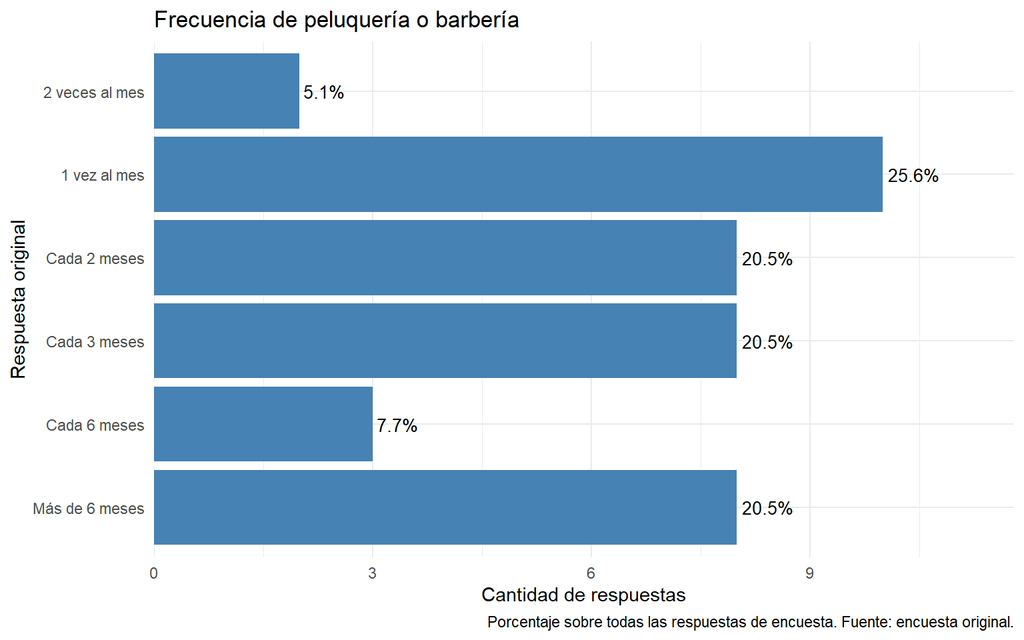

```r
resumen_peluqueria <- encuesta_descriptiva |>
  count(frec_peluqueria) |>
  mutate(porcentaje = 100 * n / sum(n), etiqueta = paste0(round(porcentaje, 1), "%"))
ggplot(resumen_peluqueria, aes(x = frec_peluqueria, y = n)) +
  geom_col(fill = "steelblue") +
  geom_text(aes(label = etiqueta), hjust = -0.1, size = 3.5) +
  coord_flip() + theme_minimal() +
  scale_y_continuous(expand = expansion(mult = c(0, 0.18))) +
  labs(title = "Frecuencia de peluquería o barbería",
       x = "Respuesta original", y = "Cantidad de respuestas",
       caption = "Porcentaje sobre todas las respuestas de encuesta. Fuente: encuesta original.")
```

Las barras corresponden a opciones de la pregunta, no a una frecuencia numérica inventada a partir de los códigos.

## Gráfica 2: edad según frecuencia de peluquería

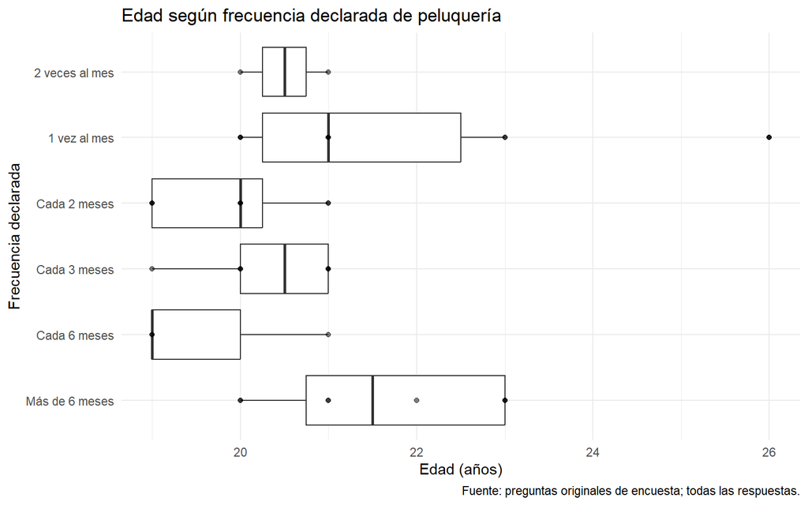

```r
ggplot(encuesta_descriptiva, aes(x = frec_peluqueria, y = edad)) +
  geom_boxplot() + geom_point(alpha = 0.5) + coord_flip() + theme_minimal() +
  labs(title = "Edad según frecuencia declarada de peluquería",
       x = "Frecuencia declarada", y = "Edad (años)",
       caption = "Fuente: preguntas originales de encuesta; todas las respuestas.")
```

El boxplot compara edades entre categorías; los puntos muestran observaciones. No unimos los códigos de frecuencia con una recta: sus distancias no son iguales.

## Gráfica 3: influencia de la ropa y adaptación al contexto

```r
resumen_confianza <- encuesta_descriptiva |>
  count(cambia_segun_personas, confianza_ropa) |>
  group_by(cambia_segun_personas) |>
  mutate(porcentaje = 100 * n / sum(n), etiqueta = paste0(round(porcentaje, 1), "%")) |>
  ungroup()
resumen_confianza
```

```
## # A tibble: 6 × 5
##   cambia_segun_personas confianza_ropa                 n porcentaje etiqueta
##   <fct>                 <fct>                      <int>      <dbl> <chr>
## 1 No                    No influye                     1       5.56 5.6%
## 2 No                    Impacto moderado              15      83.3  83.3%
## 3 No                    Influye significativamente     2      11.1  11.1%
## 4 Sí                    No influye                     2       9.52 9.5%
## 5 Sí                    Impacto moderado              13      61.9  61.9%
## 6 Sí                    Influye significativamente     6      28.6  28.6%
```

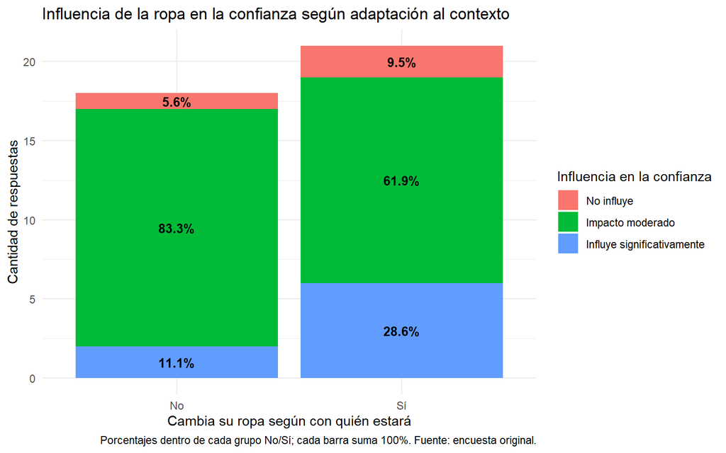

```r
ggplot(resumen_confianza, aes(x = cambia_segun_personas, y = n, fill = confianza_ropa)) +
  geom_col() +
  geom_text(aes(label = etiqueta), position = position_stack(vjust = 0.5),
            size = 3.5, fontface = "bold") +
  theme_minimal() +
  labs(title = "Influencia de la ropa en la confianza según adaptación al contexto",
       x = "Cambia su ropa según con quién estará", y = "Cantidad de respuestas",
       fill = "Influencia en la confianza",
       caption = "Porcentajes dentro de cada grupo No/Sí; cada barra suma 100%. Fuente: encuesta original.")
```

Este cruce describe dos respuestas de la encuesta. No interpreta la confianza diaria como si fuera automáticamente la seguridad de una actividad del juego.

## Gráfica 4: elecciones originales y seguridad en el juego

La versión anterior mostraba «cambio de voto», una variable calculada. La reemplazamos aquí por las elecciones originales en cada ronda. Las barras muestran cuántos eligieron cada actividad, pero no permiten identificar por sí solas quién cambió ni por qué. El análisis de cambios queda para después.

### Barras: distribución de las elecciones en cada ronda

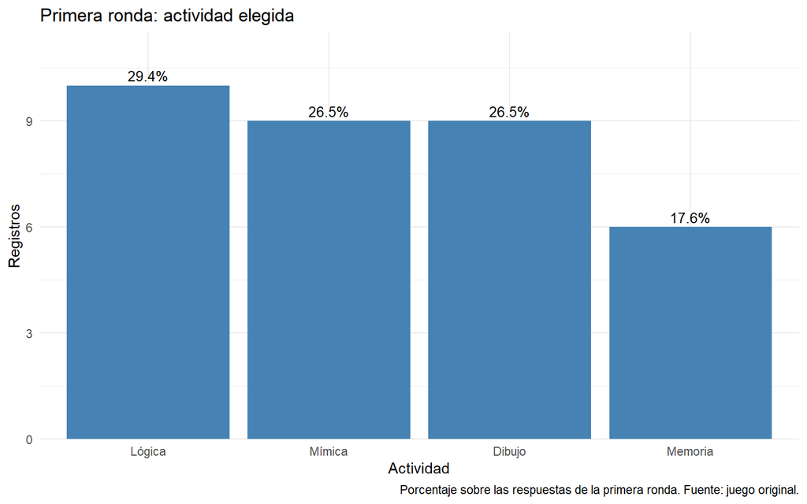

```r
resumen_eleccion_r1 <- juego_descriptivo |>
  count(ronda1_eleccion) |>
  mutate(porcentaje = 100 * n / sum(n), etiqueta = paste0(round(porcentaje, 1), "%"))
resumen_eleccion_r2 <- juego_descriptivo |>
  count(ronda2_eleccion) |>
  mutate(porcentaje = 100 * n / sum(n), etiqueta = paste0(round(porcentaje, 1), "%"))

ggplot(resumen_eleccion_r1, aes(x = ronda1_eleccion, y = n)) +
  geom_col(fill = "steelblue") +
  geom_text(aes(label = etiqueta), vjust = -0.4, size = 3.5) +
  scale_y_continuous(expand = expansion(mult = c(0, 0.15))) + theme_minimal() +
  labs(title = "Primera ronda: actividad elegida", x = "Actividad", y = "Registros",
       caption = "Porcentaje sobre las respuestas de la primera ronda. Fuente: juego original.")
```

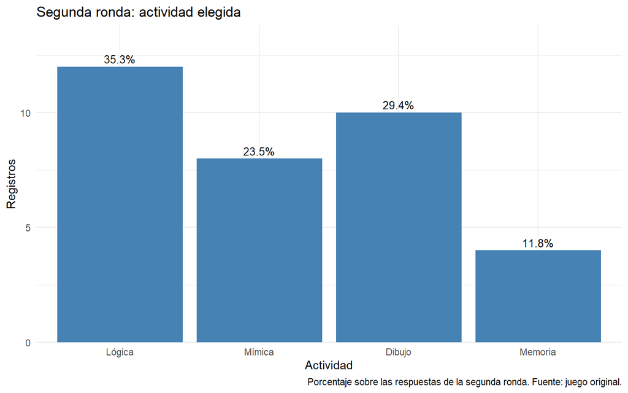

```r
ggplot(resumen_eleccion_r2, aes(x = ronda2_eleccion, y = n)) +
  geom_col(fill = "steelblue") +
  geom_text(aes(label = etiqueta), vjust = -0.4, size = 3.5) +
  scale_y_continuous(expand = expansion(mult = c(0, 0.15))) + theme_minimal() +
  labs(title = "Segunda ronda: actividad elegida", x = "Actividad", y = "Registros",
       caption = "Porcentaje sobre las respuestas de la segunda ronda. Fuente: juego original.")
```

### Boxplots complementarios: seguridad declarada por actividad

Un boxplot de dos variables binarias aporta poco: solo tendría ceros y unos. Sí complementa las barras al mostrar cómo se distribuye la **seguridad original de 1 a 5** dentro de cada actividad elegida. Es una escala ordinal; los puntos permiten ver las respuestas y el efecto de tener pocos casos. No interpreta los códigos de actividad como números ni convierte la escala de seguridad en una medida continua exacta.

```r
juego_descriptivo |> count(ronda1_eleccion)
```

```
## # A tibble: 4 × 2
##   ronda1_eleccion     n
##   <fct>           <int>
## 1 Lógica             10
## 2 Mímica              9
## 3 Dibujo              9
## 4 Memoria             6
```

```r
juego_descriptivo |> count(ronda2_eleccion)
```

```
## # A tibble: 4 × 2
##   ronda2_eleccion     n
##   <fct>           <int>
## 1 Lógica             12
## 2 Mímica              8
## 3 Dibujo             10
## 4 Memoria             4
```

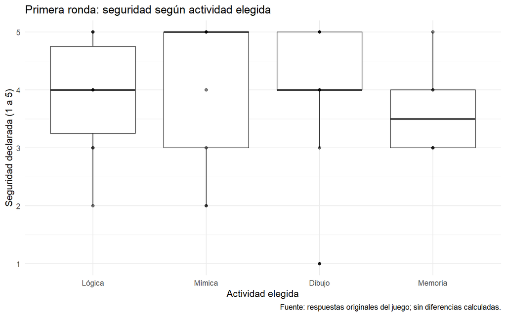

```r
ggplot(juego_descriptivo, aes(x = ronda1_eleccion, y = juego_crudo$ronda1_seguridad)) +
  geom_boxplot() + geom_point(alpha = 0.5) + theme_minimal() +
  labs(title = "Primera ronda: seguridad según actividad elegida",
       x = "Actividad elegida", y = "Seguridad declarada (1 a 5)",
       caption = "Fuente: respuestas originales del juego; sin diferencias calculadas.")
```

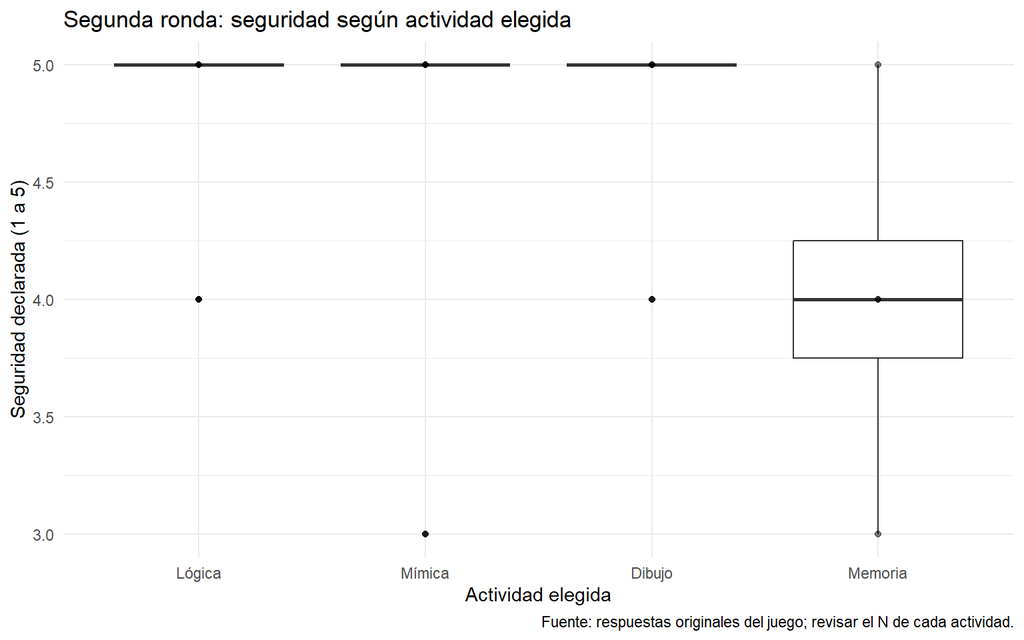

```r
ggplot(juego_descriptivo, aes(x = ronda2_eleccion, y = juego_crudo$ronda2_seguridad)) +
  geom_boxplot() + geom_point(alpha = 0.5) + theme_minimal() +
  labs(title = "Segunda ronda: seguridad según actividad elegida",
       x = "Actividad elegida", y = "Seguridad declarada (1 a 5)",
       caption = "Fuente: respuestas originales del juego; revisar el N de cada actividad.")
```

En la segunda ronda 27 de 34 respuestas declaran el máximo. Por eso algunas cajas pueden quedar aplastadas: es una concentración de las respuestas, no un error de la gráfica. Las barras y las cajas muestran cosas distintas: cantidad de elecciones y distribución de seguridad.

# Aumentación de datos

Hasta aquí no se construyó ninguna variable de análisis. Ahora aplicamos la función del archivo base a la tabla original del juego: remuestreamos filas completas con sus cuatro respuestas y su identificador. Mantener el identificador permite cruzar después cada copia con la encuesta de la misma persona; no se sortean encuesta y juego por separado, porque eso rompería la correspondencia entre personas.

```r
augment_boot <- function(data, n_new, noise = 0.1) {
  idx <- sample(nrow(data), n_new, replace = TRUE)
  out <- data[idx, ]
  num <- names(out)[sapply(out, is.numeric)]
  for (v in num) {
    out[[v]] <- out[[v]] + rnorm(n_new, 0, noise * sd(data[[v]]))
  }
  out
}
set.seed(123)
juego_boot_crudo <- augment_boot(juego_crudo, n_new = 200, noise = 0)
tibble(base = c("Juego original", "Juego remuestreado"),
       filas = c(nrow(juego_crudo), nrow(juego_boot_crudo)))
```

```
## # A tibble: 2 × 2
##   base               filas
##   <chr>              <int>
## 1 Juego original        34
## 2 Juego remuestreado   200
```

Usamos `noise = 0` porque las respuestas del juego son categorías o escalas ordinales: no les añadimos decimales ni valores fuera de rango. Las 200 filas no son nuevas personas y no corrigen la falta de representatividad. Los identificadores solo permiten seguir el origen de las copias; no se muestran en las tablas públicas.

Esto es **aumentación por remuestreo**, no recolección de otra muestra ni un intervalo bootstrap. La clase denomina **pseudorreplicación** a tratar las copias como unidades independientes. Su precisión se compara luego con la del modelo original únicamente para ilustrar ese problema.

# Modelo

## Preparación posterior a la aumentación

Recién aquí se hacen los cambios para analizar personas y modelar: validar los códigos de unión, exigir consentimiento, seleccionar una respuesta por participante, unir fuentes y construir indicadores. Son copias de trabajo: las tablas, las gráficas anteriores y los archivos originales no se reemplazan. La misma regla de preparación se aplica a las filas remuestreadas.

## Preparar las tablas

Las tablas ya tienen una columna por variable. Conservamos sus respuestas, incluidas las repetidas. La unión usa el código `id`, asignado previamente por `codigo/00_anonimizar.R`. Ese proceso pasó los correos a minúsculas y quitó espacios externos antes de asignar códigos; una misma persona mantiene el mismo código entre encuesta y juego. Aquí no se reconstruyen ni se publican los correos.

```r
encuesta <- encuesta_cruda |>
  filter(consentimiento == 1)
juego <- juego_crudo

tibble(
  tabla = c("Encuesta cruda", "Encuesta con consentimiento", "Juego"),
  filas = c(nrow(encuesta_cruda), nrow(encuesta), nrow(juego))
)
```

```
## # A tibble: 3 × 2
##   tabla                       filas
##   <chr>                       <int>
## 1 Encuesta cruda                 39
## 2 Encuesta con consentimiento    39
## 3 Juego                          34
```

```r
encuesta |> count(id) |> count(n, name = "cantidad_de_claves")
```

```
## # A tibble: 2 × 2
##       n cantidad_de_claves
##   <int>              <int>
## 1     1                 33
## 2     2                  3
```

```r
juego |> count(id) |> count(n, name = "cantidad_de_claves")
```

```
## # A tibble: 1 × 2
##       n cantidad_de_claves
##   <int>              <int>
## 1     1                 34
```

```r
# Revisar rangos sin eliminar ni reemplazar observaciones silenciosamente.
tibble(
  control = c("Edad fuera de 0 a 120", "Sexo fuera de 0/1",
              "Confianza en ropa fuera de 1 a 3", "Peluquería fuera de 1 a 10",
              "Elección R1 fuera de 1 a 4", "Elección R2 fuera de 1 a 4",
              "Seguridad R1 fuera de 1 a 5", "Seguridad R2 fuera de 1 a 5"),
  casos = c(
    sum(encuesta$edad < 0 | encuesta$edad > 120, na.rm = TRUE),
    sum(!encuesta$sexo %in% c(0, 1), na.rm = TRUE),
    sum(encuesta$confianza_ropa < 1 | encuesta$confianza_ropa > 3, na.rm = TRUE),
    sum(encuesta$frec_peluqueria < 1 | encuesta$frec_peluqueria > 10, na.rm = TRUE),
    sum(juego$ronda1_eleccion < 1 | juego$ronda1_eleccion > 4, na.rm = TRUE),
    sum(juego$ronda2_eleccion < 1 | juego$ronda2_eleccion > 4, na.rm = TRUE),
    sum(juego$ronda1_seguridad < 1 | juego$ronda1_seguridad > 5, na.rm = TRUE),
    sum(juego$ronda2_seguridad < 1 | juego$ronda2_seguridad > 5, na.rm = TRUE)
  )
)
```

```
## # A tibble: 8 × 2
##   control                          casos
##   <chr>                            <int>
## 1 Edad fuera de 0 a 120                0
## 2 Sexo fuera de 0/1                    0
## 3 Confianza en ropa fuera de 1 a 3     0
## 4 Peluquería fuera de 1 a 10           0
## 5 Elección R1 fuera de 1 a 4           0
## 6 Elección R2 fuera de 1 a 4           0
## 7 Seguridad R1 fuera de 1 a 5          0
## 8 Seguridad R2 fuera de 1 a 5          0
```

**Unidad de análisis.** La base completa sigue teniendo una fila por respuesta. Para analizar personas y ajustar modelos construimos además `encuesta_personas`: conserva la primera respuesta de cada clave en el orden del archivo, usando `distinct()` como en clase 7. Es una regla explícita de selección, no una afirmación de que esa respuesta es más correcta. Al final comparamos con la última respuesta disponible. No promediamos códigos nominales ni sumamos respuestas de una misma persona como casos independientes.

```r
encuesta_personas <- encuesta |> distinct(id, .keep_all = TRUE)
nrow(encuesta_personas)
```

```
## [1] 36
```

```r
sum(duplicated(juego$id))
```

```
## [1] 0
```

```r
# El resultado anterior debe ser 0: cada clave del juego aporta una sola fila.
```

## Unir encuesta y juego

Usamos `left_join()` con encuesta a la izquierda: conserva todas sus respuestas, aunque alguien no tenga juego. El juego no aporta nuevas personas a esa base. Para analizar el cruce usamos la versión de una respuesta por clave. Los NA de juego de alguien sin correspondencia no son ceros ni indican que no cambió de voto.

```r
base_completa <- left_join(encuesta, juego, by = "id")
base_personas <- left_join(encuesta_personas, juego, by = "id")

control_union <- tibble(
  control = c("Respuestas de encuesta", "Claves distintas en encuesta",
              "Filas de juego", "Claves distintas en juego",
              "Filas después del left join completo", "Claves con ambas fuentes",
              "Claves de encuesta sin juego", "Claves de juego sin encuesta"),
  N = c(nrow(encuesta), nrow(encuesta_personas), nrow(juego),
        n_distinct(juego$id), nrow(base_completa),
        sum(encuesta_personas$id %in% juego$id),
        sum(!encuesta_personas$id %in% juego$id),
        sum(!juego$id %in% encuesta_personas$id))
)
control_union
```

```
## # A tibble: 8 × 2
##   control                                  N
##   <chr>                                <int>
## 1 Respuestas de encuesta                  39
## 2 Claves distintas en encuesta            36
## 3 Filas de juego                          34
## 4 Claves distintas en juego               34
## 5 Filas después del left join completo    39
## 6 Claves con ambas fuentes                34
## 7 Claves de encuesta sin juego             2
## 8 Claves de juego sin encuesta             0
```

En estos archivos hay 39 respuestas de encuesta y 36 claves distintas. La base completa conserva 39 filas. Hay 34 claves con ambas fuentes. Estos conteos distinguen respuestas de identificadores; la cantidad de participantes reales depende también de documentar el origen de los registros.

## Variables calculadas para el análisis posterior

Los indicadores siguientes no eran preguntas. Se construyen ahora, después de la aumentación, a partir de respuestas existentes. Mantenemos separados los dos conceptos de seguridad: la influencia de la ropa en la confianza diaria y la seguridad de la elección en el juego.

| Variable de análisis | Cálculo o codificación | Qué representa |
| --- | --- | --- |
| `id` | P + número, asignado previamente en `codigo/00_anonimizar.R` | Código de participante y clave de unión |
| `sexo_grupo` | 0 = Femenino; 1 = Masculino | Etiqueta del código de encuesta |
| `peluqueria` | Factor con etiquetas del diccionario | Frecuencia por categoría, no número de visitas |
| `confianza_grupo` | 1 = No influye; 2 = Impacto moderado; 3 = Influye significativamente | Influencia declarada de la ropa |
| `cambio_voto` | 1 si elección R1 difiere de R2; 0 si coincide | Cambio de primera opción |
| `cambio_seguridad` | Seguridad R2 menos seguridad R1 | Cambio en puntos de la escala del juego |

```r
preparar <- function(datos) {
  datos |>
    mutate(
      sexo_grupo = factor(sexo, levels = c(0, 1), labels = c("Femenino", "Masculino")),
      peluqueria = factor(frec_peluqueria, levels = 1:10,
        labels = c("Más de 6 meses", "Cada 6 meses", "Cada 5 meses",
                   "Cada 4 meses", "Cada 3 meses", "Cada 2 meses",
                   "1 vez al mes", "2 veces al mes", "1 vez a la semana",
                   "Más de 1 vez a la semana")),
      confianza_grupo = factor(confianza_ropa, levels = 1:3,
        labels = c("No influye", "Impacto moderado", "Influye significativamente")),
      cambio_voto = as.numeric(ronda1_eleccion != ronda2_eleccion),
      cambio_seguridad = ronda2_seguridad - ronda1_seguridad
    )
}
base_personas <- preparar(base_personas)
cruce <- base_personas |> filter(id %in% juego$id)

# Segundo perfilado: verificar la tabla final después de limpiar y unir.
perfil(base_personas)
```

```
## # A tibble: 43 × 6
##    variable             tipo      distintos faltantes minimo maximo
##    <chr>                <chr>         <int>     <int>  <dbl>  <dbl>
##  1 id                   character        36         0     NA     NA
##  2 fecha_respuesta      character        36         0     NA     NA
##  3 consentimiento       numeric           1         0      1      1
##  4 sexo                 numeric           2         0      0      1
##  5 edad                 numeric           6         0     19     26
##  6 anio_carrera         numeric           4         0      2      5
##  7 carrera              numeric           5         0      1      6
##  8 carrera_otro_detalle logical           0        36     NA     NA
##  9 frec_peluqueria      numeric           6         0      1      8
## 10 se_peina             numeric           2         0      0      1
## # ℹ 33 more rows
```

## Preparar las bases original y aumentada del modelo

`df` conserva los casos originales completos en Y y X. `df_boot` se obtiene uniendo cada fila de juego remuestreada con la respuesta de encuesta seleccionada de su propio código. No se crea una correspondencia al azar.

```r
df <- cruce |>
  select(ronda1_seguridad, confianza_ropa, cambia_segun_personas) |> na.omit()

juego_boot <- juego_boot_crudo
cruce_boot <- left_join(juego_boot, encuesta_personas, by = "id")
df_boot <- cruce_boot |>
  select(ronda1_seguridad, confianza_ropa, cambia_segun_personas) |> na.omit()

tibble(
  base = c("Original del modelo", "Aumentada del modelo"),
  filas = c(nrow(df), nrow(df_boot)),
  excluidas_por_faltantes_en_Y_X = c(nrow(cruce) - nrow(df), nrow(cruce_boot) - nrow(df_boot))
)
```

```
## # A tibble: 2 × 3
##   base                 filas excluidas_por_faltantes_en_Y_X
##   <chr>                <int>                          <int>
## 1 Original del modelo     34                              0
## 2 Aumentada del modelo   200                              0
```

Se distingue la descriptiva inicial de respuestas de esta selección para el modelo. Que la primera tenga más filas no es un error: no se habían quitado las respuestas repetidas. No llamamos personas distintas a las copias.

## Asociación posterior: indicador calculado de cambio de voto

Después de preparar los datos, seguimos el bloque categórica por categórica del ejemplo: cruzamos cambiar vestimenta con cambiar voto. Revisamos las frecuencias esperadas de chi-cuadrado, como indican las diapositivas 9 y 10 de la nueva clase. Conservamos Fisher, que también es válido con celdas pequeñas, e informamos phi para separar evidencia de asociación y magnitud. Ninguno identifica una causa.

```r
tab <- table(cruce$cambia_segun_personas, cruce$cambio_voto)
tab
```

```
##
##      0  1
##   0 12  4
##   1 11  7
```

```r
chi_asociacion <- suppressWarnings(chisq.test(tab, correct = FALSE))
chi_asociacion$expected
```

```
##
##            0        1
##   0 10.82353 5.176471
##   1 12.17647 5.823529
```

```r
asociacion <- fisher.test(tab)
asociacion
```

```
##
##  Fisher's Exact Test for Count Data
##
## data:  tab
## p-value = 0.4768
## alternative hypothesis: true odds ratio is not equal to 1
## 95 percent confidence interval:
##   0.354077 11.315431
## sample estimates:
## odds ratio
##   1.873053
```

```r
# Fórmula de la diapositiva 13: phi = raíz de (chi-cuadrado / N).
# Se usa chi-cuadrado sin corrección de Yates. Así se informa phi sin
# corrección de sesgo, en lugar de la salida ajustada por defecto del paquete.
phi_original <- sqrt(as.numeric(chi_asociacion$statistic) / sum(tab))
tibble(N = sum(tab), p_Fisher = asociacion$p.value,
       phi_sin_ajuste = phi_original)
```

```
## # A tibble: 1 × 3
##       N p_Fisher phi_sin_ajuste
##   <int>    <dbl>          <dbl>
## 1    34    0.477          0.148
```

```r
cruce |> filter(!is.na(cambia_segun_personas), !is.na(cambio_voto)) |>
  group_by(cambia_segun_personas) |>
  summarise(N = n(), cambiaron = sum(cambio_voto),
            porcentaje_cambio = 100 * mean(cambio_voto), .groups = "drop")
```

```
## # A tibble: 2 × 4
##   cambia_segun_personas     N cambiaron porcentaje_cambio
##                   <dbl> <int>     <dbl>             <dbl>
## 1                     0    16         4              25
## 2                     1    18         7              38.9
```

Fisher devuelve p = 0.477. No encontramos evidencia suficiente de asociación en este cruce al nivel de 5%. La ausencia de evidencia no demuestra que la relación sea inexistente. El resultado está sujeto al tamaño y selección de los grupos y al origen de los datos. No se interpreta como que la vestimenta provoca cambios de voto.

La menor frecuencia esperada es 5.18. Todas son al menos 5: la aproximación chi-cuadrado también es aplicable; usar Fisher no es un error. Phi sin ajuste vale 0.148 en una escala de 0 a 1. En estos datos su magnitud es pequeña y se acompaña de los porcentajes de cambio de cada grupo para interpretar la diferencia en términos del juego. Una asociación pequeña en esta muestra no prueba que no exista relación en la población. El p-valor y phi responden preguntas diferentes: evidencia contra ausencia de asociación y magnitud observada, respectivamente.

## Cambios entre rondas: análisis posterior, no preguntas originales

```r
cruce |> count(cambio_voto)
```

```
## # A tibble: 2 × 2
##   cambio_voto     n
##         <dbl> <int>
## 1           0    23
## 2           1    11
```

```r
summary(cruce$cambio_seguridad)
```

```
##    Min. 1st Qu.  Median    Mean 3rd Qu.    Max.
## -1.0000  0.0000  1.0000  0.8235  1.7500  4.0000
```

En las claves originales con ambas fuentes cambiaron de elección 11 de 34. Cambiar de voto no equivale por sí solo a seguir a la mayoría. La diferencia de seguridad es un cálculo entre dos respuestas ordinales, no una pregunta que se haya hecho directamente.

## Explicar la seguridad inicial con X de la encuesta

Elegimos Y = seguridad de la primera elección. Las X son la influencia de la ropa en la confianza y cambiar la vestimenta según las personas con quienes se estará. La primera aproxima el vínculo declarado entre apariencia y seguridad; la segunda, la adaptación al contexto social. Son conceptos relacionados con la pregunta del proyecto, pero no idénticos a la decisión del juego. No seleccionamos variables para conseguir significación.

Usamos `lm()`, `summary()` y `coef()` de la clase 12. Aplicar un modelo lineal a escalas ordinales es una aproximación: supone iguales distancias entre puntos de seguridad y entre códigos de confianza. El segundo modelo trata la confianza como factor para revisar esta última decisión, con más parámetros. No incorporamos modelos que no estén en clase.

```r
datos_modelo <- df  # Casos originales preparados después de la aumentación.
nrow(datos_modelo)
```

```
## [1] 34
```

```r
nrow(cruce) - nrow(datos_modelo)  # Casos excluidos por faltantes en Y o X.
```

```
## [1] 0
```

```r
modelo <- lm(ronda1_seguridad ~ confianza_ropa + cambia_segun_personas,
             data = datos_modelo)
summary(modelo)
```

```
##
## Call:
## lm(formula = ronda1_seguridad ~ confianza_ropa + cambia_segun_personas,
##     data = datos_modelo)
##
## Residuals:
##      Min       1Q   Median       3Q      Max
## -2.29691 -0.74062  0.02208  0.78477  1.70309
##
## Coefficients:
##                       Estimate Std. Error t value Pr(>|t|)
## (Intercept)             5.1026     0.7782   6.557 2.54e-07 ***
## confianza_ropa         -0.4437     0.3536  -1.255    0.219
## cambia_segun_personas  -0.4746     0.3750  -1.265    0.215
## ---
## Signif. codes:  0 '***' 0.001 '**' 0.01 '*' 0.05 '.' 0.1 ' ' 1
##
## Residual standard error: 1.086 on 31 degrees of freedom
## Multiple R-squared:  0.102,  Adjusted R-squared:  0.04409
## F-statistic: 1.761 on 2 and 31 DF,  p-value: 0.1886
```

```r
coef(modelo)
```

```
##           (Intercept)        confianza_ropa cambia_segun_personas
##             5.1026490            -0.4437086            -0.4746137
```

```r
summary(modelo)$r.squared
```

```
## [1] 0.1020202
```

```r
modelo_categorias <- lm(ronda1_seguridad ~ factor(confianza_ropa) + cambia_segun_personas,
                        data = datos_modelo)
summary(modelo_categorias)
```

```
##
## Call:
## lm(formula = ronda1_seguridad ~ factor(confianza_ropa) + cambia_segun_personas,
##     data = datos_modelo)
##
## Residuals:
##      Min       1Q   Median       3Q      Max
## -2.29342 -0.74378  0.02895  0.78320  1.70658
##
## Coefficients:
##                         Estimate Std. Error t value Pr(>|t|)
## (Intercept)               4.6487     0.6883   6.754 1.73e-07 ***
## factor(confianza_ropa)2  -0.4319     0.6810  -0.634    0.531
## factor(confianza_ropa)3  -0.8822     0.7622  -1.157    0.256
## cambia_segun_personas    -0.4730     0.3891  -1.216    0.234
## ---
## Signif. codes:  0 '***' 0.001 '**' 0.01 '*' 0.05 '.' 0.1 ' ' 1
##
## Residual standard error: 1.104 on 30 degrees of freedom
## Multiple R-squared:  0.102,  Adjusted R-squared:  0.01224
## F-statistic: 1.136 on 3 and 30 DF,  p-value: 0.3503
```

El modelo principal usa 34 observaciones y tiene 31 grados de libertad residuales. Su R² es 0.102: describe la proporción de variación de seguridad inicial que recoge dentro de esta base.

El coeficiente de confianza en la ropa es -0.444: un punto más en su código se asocia con esa diferencia en puntos de seguridad inicial, manteniendo fija la adaptación de vestimenta. El coeficiente de adaptación es -0.475: compara quienes contestan sí con quienes contestan no, al mismo código de confianza. Son asociaciones, no efectos causales. El intercepto evalúa confianza = 0, fuera de su escala, por lo que no representa un perfil observado.

No se usa la seguridad de la segunda ronda para explicar la primera, porque se mediría después de la devolución grupal. Tampoco se estima un gran modelo con todas las preguntas: el N y la variación disponible son limitados.

### Revisar residuos y valores extremos

Como en clase 12, miramos qué deja sin explicar el modelo. No agregamos una batería de pruebas de Econometría. Los valores 1 y 5 son extremos de una escala válida: no se eliminan por estar lejos del promedio.

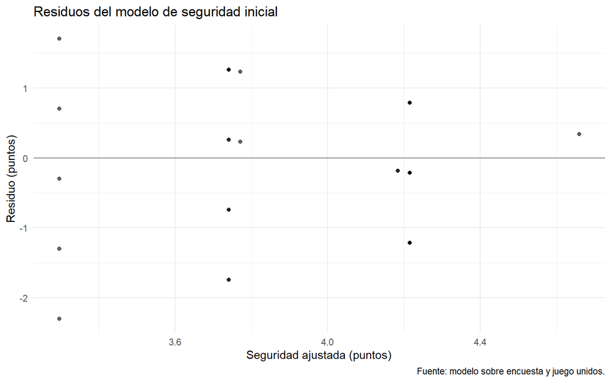

```r
datos_modelo <- datos_modelo |>
  mutate(predicho = fitted(modelo), residuo = resid(modelo))
ggplot(datos_modelo, aes(x = predicho, y = residuo)) +
  geom_hline(yintercept = 0, color = "grey50") + geom_point(alpha = 0.6) +
  theme_minimal() + labs(title = "Residuos del modelo de seguridad inicial",
    x = "Seguridad ajustada (puntos)", y = "Residuo (puntos)",
    caption = "Fuente: modelo sobre encuesta y juego unidos.")
```

```r
sd(datos_modelo$residuo)
```

```
## [1] 1.052838
```

```r
datos_modelo |> filter(abs(residuo) == max(abs(residuo)))
```

```
## # A tibble: 1 × 5
##   ronda1_seguridad confianza_ropa cambia_segun_personas predicho residuo
##              <dbl>          <dbl>                 <dbl>    <dbl>   <dbl>
## 1                1              3                     1     3.30   -2.30
```

La última tabla muestra los casos con mayor error absoluto sin revelar su identidad. Sirve para discutir qué perfiles describe peor el modelo; no es una razón automática para quitarlos. Un ajuste bajo también es informativo: la seguridad de elegir una actividad podría depender de habilidades, preferencias o vínculos grupales que la encuesta de vestimenta no mide.

### Sensibilidad a las respuestas repetidas

Conservamos las fuentes y repetimos el cálculo eligiendo la última respuesta de cada código de participante en el orden del CSV. No es una nueva muestra independiente. Las diferencias muestran cuánto depende el resultado de esa decisión.

```r
encuesta_ultima <- encuesta |> filter(!duplicated(id, fromLast = TRUE))
cruce_ultima <- left_join(encuesta_ultima, juego, by = "id") |>
  filter(id %in% juego$id) |>
  select(ronda1_seguridad, confianza_ropa, cambia_segun_personas) |> na.omit()
modelo_ultima <- lm(ronda1_seguridad ~ confianza_ropa + cambia_segun_personas,
                    data = cruce_ultima)
tibble(
  respuesta = c("Primera", "Última"),
  N = c(nrow(datos_modelo), nrow(cruce_ultima)),
  beta_confianza = c(coef(modelo)[2], coef(modelo_ultima)[2]),
  beta_adaptacion = c(coef(modelo)[3], coef(modelo_ultima)[3]),
  R2 = c(summary(modelo)$r.squared, summary(modelo_ultima)$r.squared)
)
```

```
## # A tibble: 2 × 5
##   respuesta     N beta_confianza beta_adaptacion    R2
##   <chr>     <int>          <dbl>           <dbl> <dbl>
## 1 Primera      34         -0.444          -0.475 0.102
## 2 Última       34         -0.440          -0.595 0.128
```

## Modelo sobre la base aumentada y comparación

Después de la aumentación ajustamos la misma regresión sobre `df_boot`, para completar la secuencia del archivo base. La comparamos con la regresión sobre los registros originales. Mantenemos iguales Y y X; solo cambia el conjunto de filas utilizado. La interpretación sobre participantes se apoya en los registros originales y en que su procedencia esté documentada.

```r
modelo_boot <- lm(ronda1_seguridad ~ confianza_ropa + cambia_segun_personas,
                  data = df_boot)
coef(modelo_boot)
```

```
##           (Intercept)        confianza_ropa cambia_segun_personas
##             5.3331834            -0.5560957            -0.4001176
```

```r
summary(modelo_boot)$r.squared
```

```
## [1] 0.09883235
```

```r
tibble(
  base = c("Original seleccionada", "Artificial por remuestreo"),
  filas = c(nrow(df), nrow(df_boot)),
  beta_confianza = c(coef(modelo)[2], coef(modelo_boot)[2]),
  beta_adaptacion = c(coef(modelo)[3], coef(modelo_boot)[3]),
  R2 = c(summary(modelo)$r.squared, summary(modelo_boot)$r.squared)
)
```

```
## # A tibble: 2 × 5
##   base                      filas beta_confianza beta_adaptacion     R2
##   <chr>                     <int>          <dbl>           <dbl>  <dbl>
## 1 Original seleccionada        34         -0.444          -0.475 0.102
## 2 Artificial por remuestreo   200         -0.556          -0.400 0.0988
```

Las diferencias entre coeficientes se deben a qué filas fueron seleccionadas al azar y cuántas veces se repitieron. Un resultado más favorable en la base aumentada no sería una confirmación de la hipótesis. No mezclamos sus 200 filas con las originales para declarar un N mayor de participantes.

### Errores estándar e intervalos: la precisión aparente

Como en la diapositiva 21, comparamos no solo coeficientes y R², sino también errores estándar, p-valores e intervalos. Usamos la aproximación de la clase: **coeficiente ± 2 errores estándar**. Estos son intervalos del 95% aproximados, no los intervalos exactos basados en la distribución t. Los de la base aumentada se muestran únicamente para ilustrar la falsa precisión: no son intervalos válidos para inferir sobre la población.

```r
resumen_original <- summary(modelo)$coefficients
resumen_aumentado <- summary(modelo_boot)$coefficients

comparacion_precision <- tibble(
  base = c(rep("Original", 3), rep("Aumentada: demostración", 3)),
  termino = rep(c("Intercepto", "Confianza asociada a la ropa",
                  "Cambia ropa según personas"), 2),
  coeficiente = c(resumen_original[, 1], resumen_aumentado[, 1]),
  error_estandar = c(resumen_original[, 2], resumen_aumentado[, 2]),
  p_valor = c(resumen_original[, 4], resumen_aumentado[, 4])
) |>
  mutate(IC95_aprox_inferior = coeficiente - 2 * error_estandar,
         IC95_aprox_superior = coeficiente + 2 * error_estandar)
comparacion_precision
```

```
## # A tibble: 6 × 7
##   base           termino coeficiente error_estandar  p_valor IC95_aprox_inferior
##   <chr>          <chr>         <dbl>          <dbl>    <dbl>               <dbl>
## 1 Original       Interc…       5.10           0.778 2.54e- 7               3.55
## 2 Original       Confia…      -0.444          0.354 2.19e- 1              -1.15
## 3 Original       Cambia…      -0.475          0.375 2.15e- 1              -1.22
## 4 Aumentada: de… Interc…       5.33           0.332 1.09e-37               4.67
## 5 Aumentada: de… Confia…      -0.556          0.154 3.77e- 4              -0.863
## 6 Aumentada: de… Cambia…      -0.400          0.150 8.25e- 3              -0.700
## # ℹ 1 more variable: IC95_aprox_superior <dbl>
```

```r
tibble(
  base = c("Original", "Aumentada: demostración"),
  filas = c(nrow(df), nrow(df_boot)),
  maximo_de_claves_originales_disponibles = c(nrow(df), nrow(df)),
  R2 = c(summary(modelo)$r.squared, summary(modelo_boot)$r.squared)
)
```

```
## # A tibble: 2 × 4
##   base                    filas maximo_de_claves_originales_disponibles     R2
##   <chr>                   <int>                                   <int>  <dbl>
## 1 Original                   34                                      34 0.102
## 2 Aumentada: demostración   200                                      34 0.0988
```

Para confianza asociada a la ropa, el error estándar pasa de 0.354 a 0.154, mientras que el p-valor pasa de 0.219 a 3.77^{-4}. El intervalo original aproximado va de -1.151 a 0.263; el aumentado va de -0.863 a -0.249.

En esta ejecución, confianza pasa de no ser significativa al 5% en el modelo original a parecer significativa en el aumentado. No se recogieron respuestas nuevas: una aparente ganancia de evidencia no justifica cambiar la conclusión. El remuestreo también modifica cuánto pesa cada fila, por lo que los coeficientes y el R² pueden variar; no tienen por qué ser idénticos.

Los intervalos originales expresan la incertidumbre bajo los supuestos del modelo y de independencia. Tampoco garantizan representatividad: extrapolar a todos los estudiantes requiere justificar la selección de la muestra, como indica la diapositiva 22. La aumentación no corrige una muestra de conveniencia ni permite concluir sobre perfiles que no fueron observados.

# Conclusiones y críticas según los apuntes

## Caracterización de las respuestas recibidas

La encuesta reúne 39 respuestas correspondientes a 36 códigos de participante distintos. Los porcentajes descriptivos que siguen se calculan sobre las respuestas originales, incluidas las repetidas. Por eso describen lo que recibimos y no deben presentarse como porcentajes de personas independientes ni de toda la población universitaria.

La edad media registrada es de 20.8 años. El 61.5% de las respuestas corresponde a sexo masculino y el 38.5% a femenino. Ciencia de Datos para Negocios representa el 48.7% de las respuestas y Finanzas el 38.5%. Esta composición concentra el trabajo en determinados perfiles académicos.

En los hábitos de apariencia, el 71.8% declara peinarse antes de ir a la Universidad. El 25.6% indica ir a la peluquería una vez al mes. Para elegir la ropa de facultad, el clima aparece en el 69.2% de las respuestas, el estilo y la combinación en el 69.2% y la formalidad exigida en el 7.7%. Estas preguntas permitían marcar varias opciones. El último porcentaje describe la formalidad como criterio declarado; no mide directamente cuántas personas usan ropa formal.

El 71.8% señala un impacto moderado de la ropa en su confianza diaria y el 20.5% una influencia significativa. El 53.8% declara adaptar la vestimenta según con quién estará, mientras que el 69.2% repite outfit en la semana sin problema. Estos resultados caracterizan las respuestas sobre vestimenta y cuidado de la imagen. No bastan para atribuir esas conductas a orgullo, presión social u otra causa que no se midió directamente, ni para anticipar cómo respondería una nueva muestra.

## Qué muestran los datos

El destinatario es la clase y la profesora. La afirmación central es: **el cruce permite describir cómo conviven hábitos de vestimenta y decisiones del juego, pero su diseño y el origen de los registros limitan lo que puede concluirse sobre influencia social y causalidad.**

En la descriptiva original, la ropa tiene un impacto moderado sobre la confianza para 28 de 39 respuestas. En el análisis posterior del juego hubo cambios de elección y una fuerte concentración de seguridad en la segunda ronda. La regresión recoge un R² de 0.102 para seguridad inicial, aproximadamente 10.2% de su variación en la muestra. La mayor parte de esa variación queda sin recoger por estas dos X. Estos resultados no necesitan mostrar una relación fuerte para aportar: también permiten evaluar la distancia entre lo que preguntó la encuesta y lo que captó el juego.

La comparación de precisión muestra además que el remuestreo puede hacer parecer significativa una variable que no lo era en los datos originales. Esto ilustra pseudorreplicación, no una mejora de la evidencia. Las conclusiones del proyecto se mantienen basadas en las respuestas originales y en sus límites de diseño, tamaño y medición.

## N, causalidad y objeción principal

El N relevante para el modelo es el número de claves distintas con ambas fuentes y datos válidos en Y y X; no las filas repetidas, las dos rondas contadas por separado ni las 200 copias del remuestreo. Incluso ese N solo equivale a participantes efectivos si se verifica la procedencia de los registros. No consta una variable de origen que permita separar posibles datos sintéticos ya presentes.

La encuesta es observacional y el juego no asignó aleatoriamente quién veía los resultados. Un antes y después sin grupo de comparación no separa el efecto de mostrar la votación de repetir la pregunta, conversar o cambiar de opinión. Edad, gustos, habilidades y relaciones entre compañeros podrían explicar diferencias. Una asociación o un p-valor pequeño no elimina estas alternativas.

**La objeción más fuerte** es de medición: cuidar la apariencia, adaptar la ropa al contexto y cambiar entre juegos no son la misma conducta. Aunque no aparezca la relación esperada, no podemos concluir que la apariencia no se relacione con la influencia social en otros contextos. Si tampoco está documentado qué registros son reales, la interpretación empírica queda aún más limitada.

## Qué se puede concluir sobre otra muestra o la población

Con nuestra muestra **no podemos suponer cómo respondería otra muestra independiente** ni afirmar que toda la UM tendría los mismos porcentajes o coeficientes. No consta un muestreo aleatorio ni una tasa de respuesta que permita justificar representatividad. El problema no es solo cuántas filas hay: también importa cómo se eligió a quienes participaron.

Remuestrear nuestra tabla reproduce combinaciones observadas; **no simula una nueva encuesta representativa**, no incorpora perfiles ausentes y no verifica el comportamiento de personas que no participaron. Tampoco permite validar el modelo en otra muestra. Para estudiar si los resultados se mantienen haría falta información nueva, recolectada con un diseño adecuado.

Los resultados describen estas respuestas y, en el modelo, las claves seleccionadas con ambas fuentes. Un coeficiente no significativo no prueba que no exista relación, y un coeficiente significativo en copias no prueba que sí exista. Los intervalos originales son condicionales al modelo; no corrigen el sesgo de selección ni hacen causal una asociación.

## Qué base sostiene cada resultado

| Resultado | Datos utilizados |
| --- | --- |
| Descriptiva completa de encuesta | Todas las respuestas de `encuesta_cruda`; solo etiquetas de presentación |
| Descriptiva completa del juego | Las cuatro respuestas originales de `juego_crudo` |
| Cruces y gráficas anteriores a la aumentación | Preguntas originales, sin indicadores calculados ni selección de filas |
| Cambio de voto y cambio de seguridad | Indicadores creados después de la aumentación, sobre el cruce original |
| Modelo e incertidumbre de referencia | `df`: una respuesta seleccionada por clave y casos completos |
| Demostración con filas repetidas | `df_boot`: juego remuestreado unido a la encuesta de su misma clave |

## Críticas y qué haríamos diferente

- Nos habría gustado diseñar y pilotear el juego antes de cerrar la encuesta, para que ambos instrumentos midieran aspectos comparables. El orden por sí solo no asegura mejores datos: habría que cuidar que un instrumento no condicione las respuestas del otro.
- El juego de elegir una actividad puede depender más de gustos y habilidades que del cuidado de la imagen. Elegiríamos decisiones con un vínculo más directo con la autoimagen y registraríamos por qué se cambia de elección.
- La concentración de seguridad en 5 en la segunda ronda reduce la variación. Revisaríamos las instrucciones y los anclajes de la escala con un piloto, sin cambiar respuestas ya recogidas ni forzar un resultado distinto.
- Mejoraríamos las opciones de tiempo de arreglo: falta el tramo de 30 a 60 minutos. También evitaríamos categorías solapadas como noche anterior y un día antes, y separaríamos respuestas laborales reales de hipotéticas.
- Ya usamos códigos de participante para no publicar los correos. Definiríamos de antemano una regla para respuestas repetidas y registraríamos invitaciones, no respuestas y participantes que completaron solo uno de los instrumentos.
- Guardaríamos por separado los datos observados y los sintéticos, con una columna de origen y documentación de su generación. Recolectar más casos reales aportaría información que la aumentación no puede crear.
- Para estudiar el efecto de mostrar resultados, propondríamos una comparación con asignación aleatoria de la devolución, como en el contenido de experimentos de clase. Ese diseño sería un trabajo futuro, no una propiedad del juego actual.

## Referencias de código y decisiones

| Material local | Uso en este informe |
| --- | --- |
| `codigo/analisis datos experimento.Rmd` | Estructura descriptiva, Fisher, phi y remuestreo |
| `clases/clase3/clase_cargar_datos_R.qmd` | Lectura de CSV y Excel |
| `clases/clase5/clase5_cargadatos2.R` | Perfilado con tipos, distintos y faltantes |
| `clases/clase7/carga_y_transformacion.R` | Limpieza por diccionario, duplicados, agrupación |
| `clases/clase8/pautas_equipos.qmd` | Documentación del proceso, alcance y crítica del propio trabajo |
| `clases/clase9/union_y_graficos_por_grupo.R` | Uniones, puntos, cajas y subgrupos |
| `clases/clase9/visualizacion_densidad_barras_caja.R` | Gráficas de barras y caja |
| `clases/clase12/analisis_transito_aire.R` | Regresión simple y múltiple, factores, R² y residuos |
| Nueva clase: *Análisis de datos de una encuesta o experimento: descripción, asociación y aumentación de datos* | Diap. 7–13: revisión previa, tests y tamaño de efecto; diap. 14–23: aumentación, pseudorreplicación, precisión y alcance |

El R Markdown original y los archivos de datos se mantienen como referencia. Todos los resultados se recalculan desde las fuentes al tejer este archivo.